# Détection de spams

Kezhan SHI

21 novembre 2015

# 1 Introduction

Quelques algorithmes de machine learning sont illustrés pour la problématique de détecter de spams.

La base de données initiale doit être un ensemble de mails. Le text-mining permet ensuite de nettoyer les textes afin de construire une matrix de caractéristiques. Les caractéristiques peuvent être de plusieurs types :

- Fréquences de certains mots
- Fréquences de certains caractères spéciaux
- Fréquences de lettre en capital, pour notamment détecter si le mail est écrit tout en majuscule
- Répétition de lettre dans un mot (comme merciiiiiiiii)

Concernant les mails, on peut également construire d’autres caractéristiques :

- Adresse mail de l’expéditeur : la composition de l’adresse, le nom de domaine, etc.
- Heure d’envoi du mail
- Destinataire : le nombre de destinataire, destination principale ou en copie
- Titre du mail
- Signature
- Images

La construction de la matrice de caractéristiques est souvent appelé *feature engineering* en anglais. C’est une étape primordiale. Ici, nous allons utiliser une base de données connue en data-mining : spambase de George Forman, construit sur un ensemble de mails reçus chez Hewlett-Packard Labs.

# 2 Exploration de la base de données

On peut télécharger la base de données sur le site de [UC Irvine Machine Learning Repository](https://archive.ics.uci.edu/ml/datasets/Spambase).

```r
data=read.table("spambase.data",header=F,sep=",")
names=read.csv2("names.csv",header=F)
names
```

```
##                            V1
## 1              word_freq_make
## 2           word_freq_address
## 3               word_freq_all
## 4                word_freq_3d
## 5               word_freq_our
## 6              word_freq_over
## 7            word_freq_remove
## 8          word_freq_internet
## 9             word_freq_order
## 10             word_freq_mail
## 11          word_freq_receive
## 12             word_freq_will
## 13           word_freq_people
## 14           word_freq_report
```

[output cut: 43 more lines]

```r
colnames(data)=c(as.character(names[,1]),"class")
dim(data)
```

```
## [1] 4601   58
```

```r
data$class=as.factor(as.character(data$class))

table(data$class)
```

```
##
##    0    1
## 2788 1813
```

# 3 Construction des modèles

## 3.1 Base d’apprentissage

```r
ind=createDataPartition(data$class, times = 1,p = 0.3,list=FALSE)
a=data[ind,]
t=data[-ind,]
dim(a);dim(t)
```

```
## [1] 1381   58
```

```
## [1] 3220   58
```

## 3.2 Arbres de classification

### 3.2.1 Apprentissage de l’arbre de décision

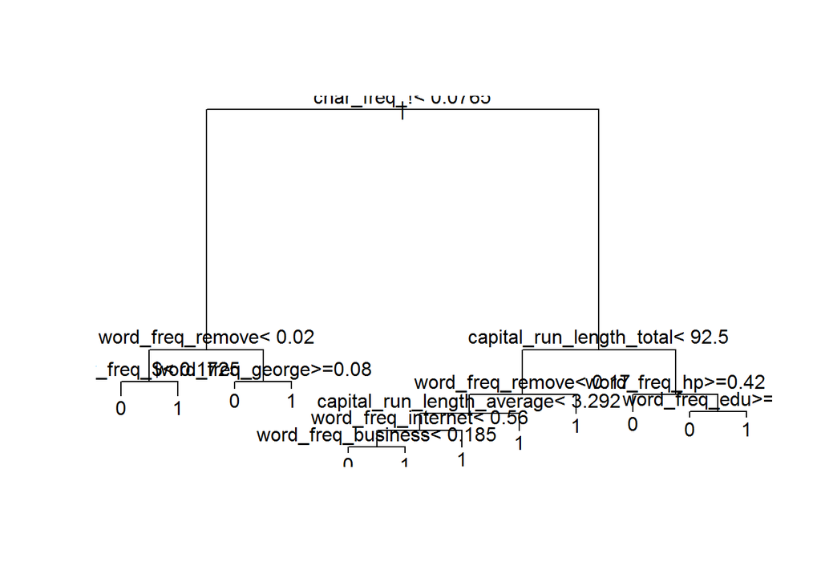

```r
formula=as.formula(class ~.)

fit.ct <- rpart(formula, a, method = "class")

# On affiche l'arbre
plot(fit.ct)
# On affiche l'arbre avec les valeurs
text(fit.ct)
```

Pour afficher un arbre plus esthétique :

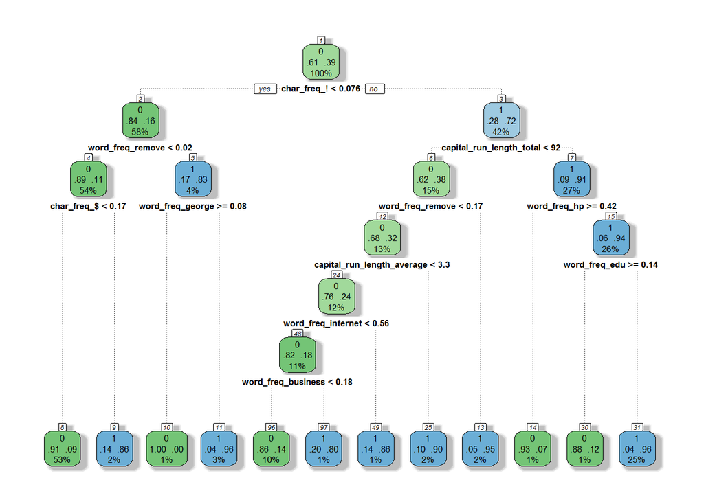

```r
fancyRpartPlot(fit.ct,main="",sub="")
```

### 3.2.2 Matrice de confusion

```r
mc.ct.a=confusionMatrix(predict(fit.ct,type="class"),a$class)
mc.ct.t=confusionMatrix(predict(fit.ct,newdata=t,type="class"),t$class)
mc.ct.a
```

```
## Confusion Matrix and Statistics
##
##           Reference
## Prediction   0   1
##          0 812  87
##          1  25 457
##
##                Accuracy : 0.9189
##                  95% CI : (0.9032, 0.9328)
##     No Information Rate : 0.6061
##     P-Value [Acc > NIR] : < 2.2e-16
##
##                   Kappa : 0.8267
##  Mcnemar's Test P-Value : 8.216e-09
##
##             Sensitivity : 0.9701
##             Specificity : 0.8401
##          Pos Pred Value : 0.9032
##          Neg Pred Value : 0.9481
##              Prevalence : 0.6061
##          Detection Rate : 0.5880
##    Detection Prevalence : 0.6510
##       Balanced Accuracy : 0.9051
##
##        'Positive' Class : 0
##
```

```r
mc.ct.t
```

```
## Confusion Matrix and Statistics
##
##           Reference
## Prediction    0    1
##          0 1843  214
##          1  108 1055
##
##                Accuracy : 0.9
##                  95% CI : (0.8891, 0.9102)
##     No Information Rate : 0.6059
##     P-Value [Acc > NIR] : < 2.2e-16
##
##                   Kappa : 0.7875
##  Mcnemar's Test P-Value : 4.874e-09
##
##             Sensitivity : 0.9446
##             Specificity : 0.8314
##          Pos Pred Value : 0.8960
##          Neg Pred Value : 0.9071
##              Prevalence : 0.6059
##          Detection Rate : 0.5724
##    Detection Prevalence : 0.6388
##       Balanced Accuracy : 0.8880
##
##        'Positive' Class : 0
##
```

### 3.2.3 Prédiction des résultats en terme de probabilité

```r
head(predict(fit.ct,type="prob"))
```

```
##             0         1
## 1  0.03724928 0.9627507
## 5  0.03724928 0.9627507
## 16 0.03724928 0.9627507
## 17 0.03724928 0.9627507
## 21 0.09523810 0.9047619
## 28 0.04545455 0.9545455
```

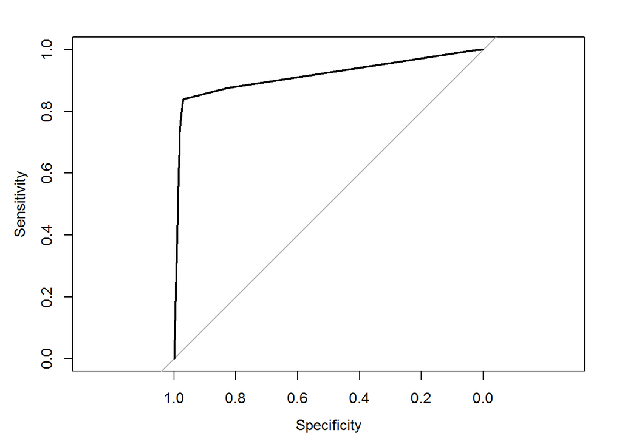

```
##
## Call:
## roc.default(response = a$class, predictor = predict(fit.ct, data = a,     type = "prob")[, 1])
##
## Data: predict(fit.ct, data = a, type = "prob")[, 1] in 837 controls (a$class 0) > 544 cases (a$class 1).
## Area under the curve: 0.9148
```

```r
roc.ct=roc(a$class,predict(fit.ct,data=a,type="prob")[,1])
plot(roc.ct)
```

### 3.2.4 Optimisation

Si on réduit la profondeur de l’arbre à 2 :

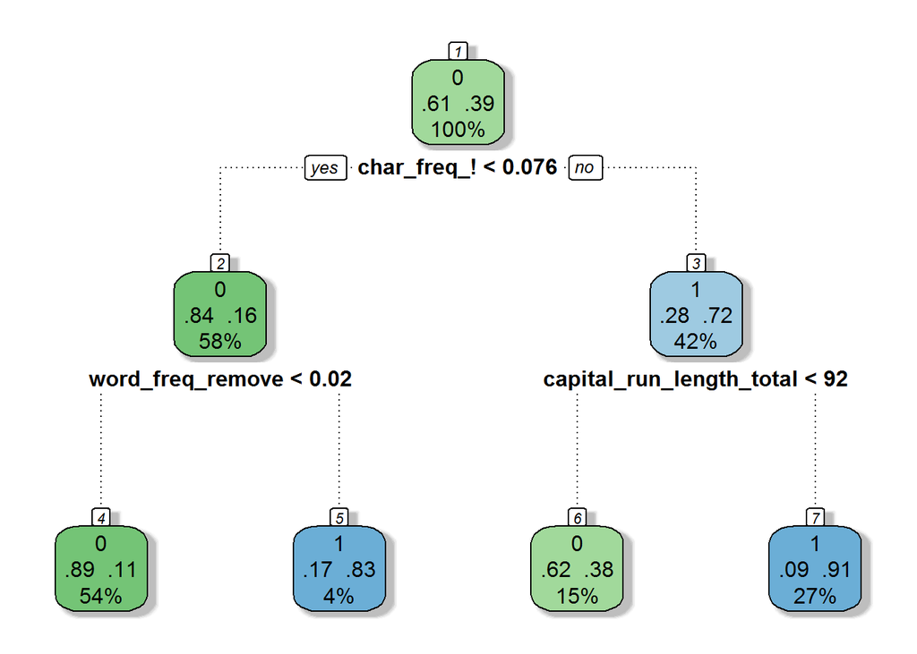

```r
fit.ct=rpart(formula,a,method = "class",
             control=rpart.control(maxdepth = 2))
fancyRpartPlot(fit.ct,main="",sub="")
```

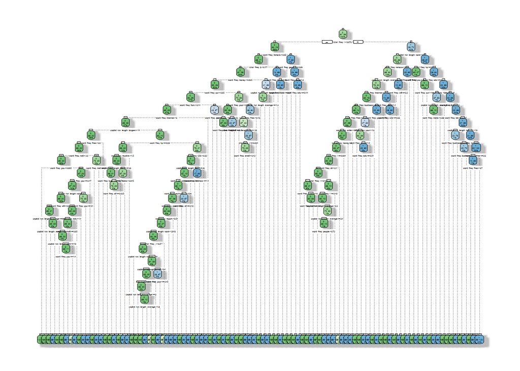

```r
fit.ct=rpart(formula,a,method = "class",
              control=rpart.control(minsplit=3, cp=0.000))
fancyRpartPlot(fit.ct,main="",sub="")
```

```r
#summary(fit.ct)
printcp(fit.ct)
```

```
##
## Classification tree:
## rpart(formula = formula, data = a, method = "class", control = rpart.control(minsplit = 3,
##     cp = 0))
##
## Variables actually used in tree construction:
##  [1] capital_run_length_average capital_run_length_longest
##  [3] capital_run_length_total   char_freq_!
##  [5] char_freq_$                char_freq_(
##  [7] char_freq_;                word_freq_1999
##  [9] word_freq_650              word_freq_address
## [11] word_freq_addresses        word_freq_all
## [13] word_freq_business         word_freq_data
## [15] word_freq_edu              word_freq_email
## [17] word_freq_font             word_freq_free
```

[output cut: 37 more lines]

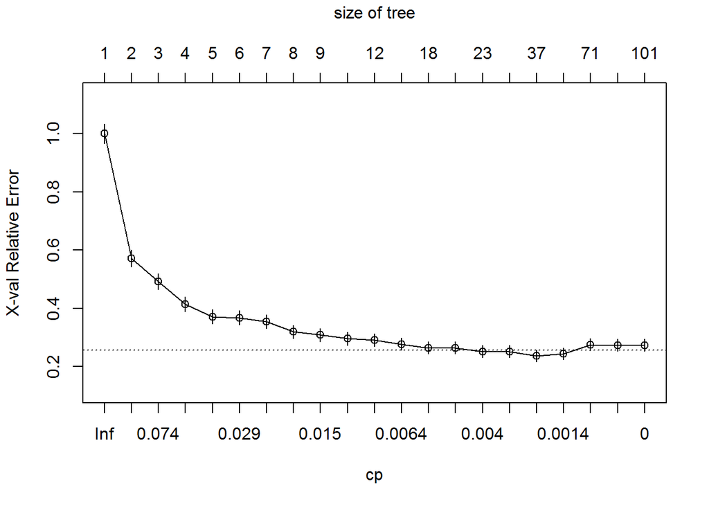

```r
plotcp(fit.ct)
```

## 3.3 SVM

### 3.3.1 Apprentissage

```r
library(kernlab)
fit.svm=ksvm(class~.,a)
```

### 3.3.2 Prédictions

```r
mc.svm.a=confusionMatrix(predict(fit.svm,type="response"),a$class)
mc.svm.t=confusionMatrix(predict(fit.svm,newdata=t,type="response"),t$class)

mc.svm.a
```

```
## Confusion Matrix and Statistics
##
##           Reference
## Prediction   0   1
##          0 818  55
##          1  19 489
##
##                Accuracy : 0.9464
##                  95% CI : (0.9332, 0.9577)
##     No Information Rate : 0.6061
##     P-Value [Acc > NIR] : < 2.2e-16
##
##                   Kappa : 0.8865
##  Mcnemar's Test P-Value : 4.728e-05
##
##             Sensitivity : 0.9773
##             Specificity : 0.8989
##          Pos Pred Value : 0.9370
##          Neg Pred Value : 0.9626
##              Prevalence : 0.6061
##          Detection Rate : 0.5923
##    Detection Prevalence : 0.6322
##       Balanced Accuracy : 0.9381
##
##        'Positive' Class : 0
##
```

```r
mc.svm.t
```

```
## Confusion Matrix and Statistics
##
##           Reference
## Prediction    0    1
##          0 1884  183
##          1   67 1086
##
##                Accuracy : 0.9224
##                  95% CI : (0.9126, 0.9314)
##     No Information Rate : 0.6059
##     P-Value [Acc > NIR] : < 2.2e-16
##
##                   Kappa : 0.8348
##  Mcnemar's Test P-Value : 3.51e-13
##
##             Sensitivity : 0.9657
##             Specificity : 0.8558
##          Pos Pred Value : 0.9115
##          Neg Pred Value : 0.9419
##              Prevalence : 0.6059
##          Detection Rate : 0.5851
##    Detection Prevalence : 0.6419
##       Balanced Accuracy : 0.9107
##
##        'Positive' Class : 0
##
```

## 3.4 Regression Logistique

### 3.4.1 Apprentissage

```r
fit.glm=glm(class~.,family=binomial(link="logit"),a)
summary(fit.glm)
```

```
##
## Call:
## glm(formula = class ~ ., family = binomial(link = "logit"), data = a)
##
## Deviance Residuals:
##     Min       1Q   Median       3Q      Max
## -4.0461  -0.1816   0.0000   0.0536   3.0689
##
## Coefficients:
##                              Estimate Std. Error z value Pr(>|z|)
## (Intercept)                -1.667e+00  2.681e-01  -6.219 5.02e-10 ***
## word_freq_make             -1.598e+00  6.398e-01  -2.498 0.012505 *
## word_freq_address          -1.901e-01  1.743e-01  -1.091 0.275321
## word_freq_all              -3.904e-01  2.534e-01  -1.540 0.123446
## word_freq_3d                1.139e+00  2.055e+00   0.554 0.579406
## word_freq_our               2.662e-01  1.492e-01   1.784 0.074391 .
## word_freq_over              1.888e-01  2.997e-01   0.630 0.528703
## word_freq_remove            4.334e+00  1.026e+00   4.222 2.42e-05 ***
## word_freq_internet          1.375e+00  5.251e-01   2.619 0.008819 **
## word_freq_order             1.358e+00  7.427e-01   1.829 0.067410 .
## word_freq_mail              4.067e-02  9.903e-02   0.411 0.681282
## word_freq_receive           9.248e-02  5.786e-01   0.160 0.873022
## word_freq_will             -2.429e-01  1.620e-01  -1.500 0.133677
## word_freq_people           -2.806e-01  4.385e-01  -0.640 0.522283
## word_freq_report            1.677e-01  3.252e-01   0.516 0.606154
## word_freq_addresses         6.954e+00  2.494e+00   2.789 0.005291 **
## word_freq_free              7.099e-01  2.580e-01   2.751 0.005933 **
## word_freq_business          1.241e+00  4.856e-01   2.556 0.010595 *
## word_freq_email            -6.420e-01  3.267e-01  -1.965 0.049374 *
## word_freq_you               1.139e-01  7.346e-02   1.551 0.120981
## word_freq_credit            1.079e+00  1.108e+00   0.974 0.329902
## word_freq_your              3.902e-01  1.188e-01   3.284 0.001022 **
## word_freq_font              3.418e-01  3.668e-01   0.932 0.351472
## word_freq_000               5.386e-01  5.683e-01   0.948 0.343269
## word_freq_money             1.660e+00  7.168e-01   2.316 0.020562 *
## word_freq_hp               -2.794e+00  7.031e-01  -3.974 7.05e-05 ***
## word_freq_hpl              -1.296e+00  8.223e-01  -1.576 0.114992
## word_freq_george           -2.752e+00  1.081e+00  -2.545 0.010919 *
## word_freq_650               3.404e-01  4.928e-01   0.691 0.489640
## word_freq_lab              -4.298e+00  4.102e+00  -1.048 0.294798
```

[output cut: 23 more lines]

```
## `char_freq_$`               7.878e+00  2.091e+00   3.767 0.000165 ***
## `char_freq_#`               2.692e-01  1.275e+00   0.211 0.832789
## capital_run_length_average -2.907e-02  2.921e-02  -0.995 0.319655
## capital_run_length_longest  2.046e-02  5.738e-03   3.567 0.000362 ***
## capital_run_length_total    7.981e-04  4.130e-04   1.933 0.053272 .
## ---
## Signif. codes:  0 '***' 0.001 '**' 0.01 '*' 0.05 '.' 0.1 ' ' 1
##
## (Dispersion parameter for binomial family taken to be 1)
##
##     Null deviance: 1851.83  on 1380  degrees of freedom
## Residual deviance:  488.82  on 1323  degrees of freedom
## AIC: 604.82
##
## Number of Fisher Scoring iterations: 23
```

### 3.4.2 Prédictions

```r
mc.glm.a=confusionMatrix(
  ifelse(predict(fit.glm,type="response")>0.5,1,0),
  a$class)
mc.glm.t=confusionMatrix(
  ifelse(predict(fit.glm,newdata=t,type="response")>0.5,1,0),
  t$class)

mc.glm.a
```

```
## Confusion Matrix and Statistics
##
##           Reference
## Prediction   0   1
##          0 798  64
##          1  39 480
##
##                Accuracy : 0.9254
##                  95% CI : (0.9103, 0.9387)
##     No Information Rate : 0.6061
##     P-Value [Acc > NIR] : < 2e-16
##
##                   Kappa : 0.8425
##  Mcnemar's Test P-Value : 0.01804
##
##             Sensitivity : 0.9534
##             Specificity : 0.8824
##          Pos Pred Value : 0.9258
##          Neg Pred Value : 0.9249
##              Prevalence : 0.6061
##          Detection Rate : 0.5778
##    Detection Prevalence : 0.6242
##       Balanced Accuracy : 0.9179
##
##        'Positive' Class : 0
##
```

```r
mc.glm.t
```

```
## Confusion Matrix and Statistics
##
##           Reference
## Prediction    0    1
##          0 1841  158
##          1  110 1111
##
##                Accuracy : 0.9168
##                  95% CI : (0.9067, 0.9261)
##     No Information Rate : 0.6059
##     P-Value [Acc > NIR] : < 2.2e-16
##
##                   Kappa : 0.8246
##  Mcnemar's Test P-Value : 0.004092
##
##             Sensitivity : 0.9436
##             Specificity : 0.8755
##          Pos Pred Value : 0.9210
##          Neg Pred Value : 0.9099
##              Prevalence : 0.6059
##          Detection Rate : 0.5717
##    Detection Prevalence : 0.6208
##       Balanced Accuracy : 0.9096
##
##        'Positive' Class : 0
##
```

## 3.5 Analyse Discriminante

```r
fit.lda=lda(class~.,data=a)
```

```r
mc.lda.a=confusionMatrix(predict(fit.lda,data=a)$class,a$class)
mc.lda.t=confusionMatrix(predict(fit.lda,newdata=t)$class,t$class)
```

## 3.6 kNN

### 3.6.1 Normalisation

On peut normaliser les valeurs à l’aide la fonction suivante :

```r
normalize <- function(x) {
    norm <- ((x - min(x))/(max(x) - min(x)))
    return (norm)
}

datan <- as.data.frame(lapply(data[,1:57], normalize))
```

Ainsi toutes les variables prennent des valeurs de 0 à 1 :

```r
data_n=cbind(datan,class=data[,58])
```

### 3.6.2 Création de partition

Pour tester l’algorithme, on répartit les données en deux bases : base d’apprentissage et base de test.

```r
a_n=data_n[ind,]
t_n=data_n[-ind,]
```

### 3.6.3 Prédiction

On peut faire la prédiction des classes de la base de test à l’aide la fonction `knn` du package `class`. On peut choisir dans un premier temps `k=5`.

```r
pred.a <- knn(train = a_n[,1:57], test = a_n[,1:57],
 cl = a_n$class, k=5)
pred.t <- knn(train = a_n[,1:57], test = t_n[,1:57],
 cl = a_n$class, k=5)
```

ou utiliser la fonction `confusionMatrix` qui permet de calculer automatiquement certains caractéristiques :

```r
mc.knn.a=(confusionMatrix(pred.a,a_n$class))
mc.knn.t=(confusionMatrix(pred.t,t_n$class))
```

## 3.7 Classification Naïve bayésienne

```r
fit.nb <- naiveBayes(class ~ ., data = a)

mc.nb.a=confusionMatrix(predict(fit.nb,a),a$class)
mc.nb.t=confusionMatrix(predict(fit.nb,newdata=t),t$class)
```

# 4 Synthèse des modèles

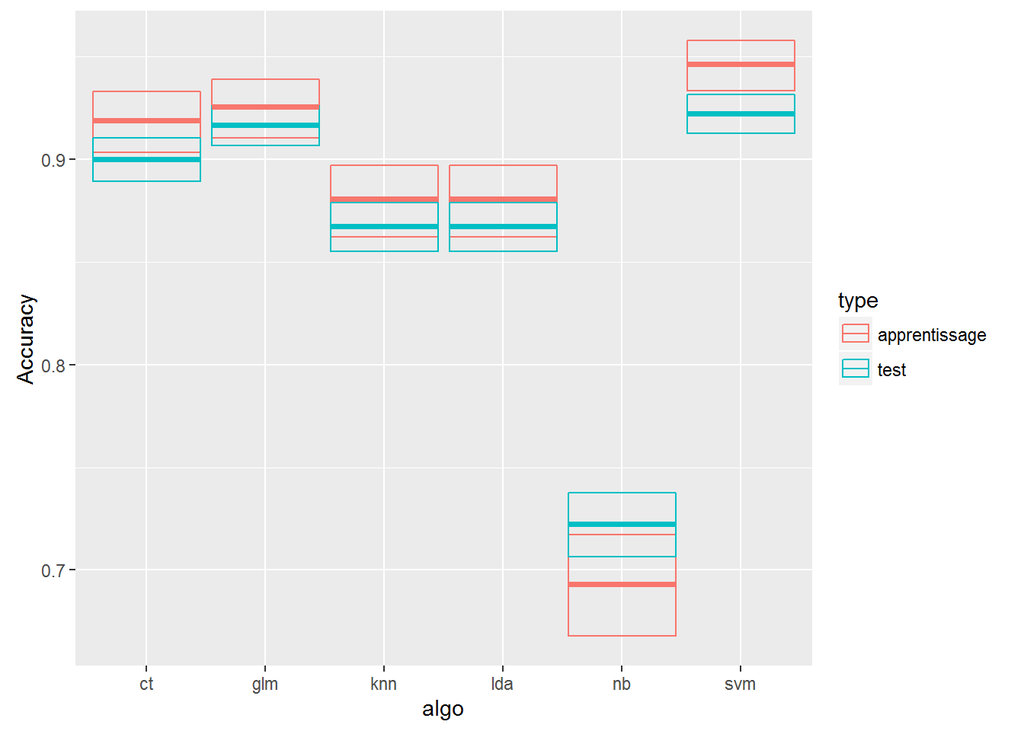

```r
df=as.data.frame(rbind(c("ct","apprentissage",mc.ct.a$overall[c("AccuracyLower","Accuracy","AccuracyUpper")]),
c("ct","test",mc.ct.t$overall[c("AccuracyLower","Accuracy","AccuracyUpper")]),

c("svm","apprentissage",mc.svm.a$overall[c("AccuracyLower","Accuracy","AccuracyUpper")]),
c("svm","test",mc.svm.t$overall[c("AccuracyLower","Accuracy","AccuracyUpper")]),

c("glm","apprentissage",mc.glm.a$overall[c("AccuracyLower","Accuracy","AccuracyUpper")]),
c("glm","test",mc.glm.t$overall[c("AccuracyLower","Accuracy","AccuracyUpper")]),

c("lda","apprentissage",mc.lda.a$overall[c("AccuracyLower","Accuracy","AccuracyUpper")]),
c("lda","test",mc.knn.t$overall[c("AccuracyLower","Accuracy","AccuracyUpper")]),
c("knn","apprentissage",mc.lda.a$overall[c("AccuracyLower","Accuracy","AccuracyUpper")]),
c("knn","test",mc.knn.t$overall[c("AccuracyLower","Accuracy","AccuracyUpper")]),
c("nb","apprentissage",mc.nb.a$overall[c("AccuracyLower","Accuracy","AccuracyUpper")]),
c("nb","test",mc.nb.t$overall[c("AccuracyLower","Accuracy","AccuracyUpper")])
))

colnames(df)[1:2]=c("algo","type")
df[,"AccuracyLower"]=as.numeric(as.character(df[,"AccuracyLower"]))
df[,"Accuracy"]=as.numeric(as.character(df[,"Accuracy"]))
df[,"AccuracyUpper"]=as.numeric(as.character(df[,"AccuracyUpper"]))

p <- ggplot(df, aes(algo, Accuracy, colour = type))
p + geom_crossbar(aes(ymin = AccuracyLower, ymax = AccuracyUpper))
```

# 5 Agrégation de modèles

## 5.1 Bagging

```r
fit.bag=bagging(class ~.,a,nbagg=60)
mc.bag.a=confusionMatrix(predict(fit.bag,data=a),a$class)
mc.bag.t=confusionMatrix(predict(fit.bag,newdata=t),t$class)
```

## 5.2 Foret Aleatoire

```r
colnames(a)[49:54]=paste0("v_",seq(1:6))
colnames(t)[49:54]=paste0("v_",seq(1:6))

fit.rf=randomForest(class~.,data=a)

mc.rf.a=confusionMatrix(predict(fit.rf,data=a,type="class"),a$class)
mc.rf.t=confusionMatrix(predict(fit.rf,newdata=t,type="class"),t$class)
```

# 6 Synthèse Finale

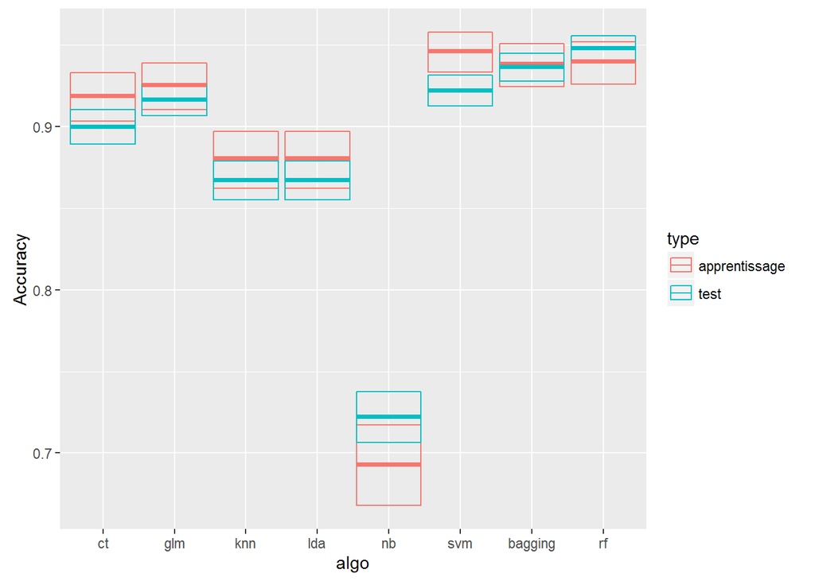

```r
df2=as.data.frame(rbind(c("bagging","apprentissage",mc.bag.a$overall[c("AccuracyLower","Accuracy","AccuracyUpper")]),
c("bagging","test",mc.bag.t$overall[c("AccuracyLower","Accuracy","AccuracyUpper")]),

c("rf","apprentissage",mc.rf.a$overall[c("AccuracyLower","Accuracy","AccuracyUpper")]),
c("rf","test",mc.rf.t$overall[c("AccuracyLower","Accuracy","AccuracyUpper")])))

df2[,"AccuracyLower"]=as.numeric(as.character(df2[,"AccuracyLower"]))
df2[,"Accuracy"]=as.numeric(as.character(df2[,"Accuracy"]))
df2[,"AccuracyUpper"]=as.numeric(as.character(df2[,"AccuracyUpper"]))

colnames(df2)[1:2]=c("algo","type")

p <- ggplot(rbind(df,df2), aes(algo, Accuracy, colour = type))
p + geom_crossbar(aes(ymin = AccuracyLower, ymax = AccuracyUpper))
```